# BMW vs VOLKSWAGEN

Antonio Pascual Hernández

26/11/2020

## 1. Introducción

Utilizando datos diarios de los dos series desde el año 2014, debemos analizar la relación entre BMW y Volkswagen, estimando el modelo garch de BMW, estudiar si están cointegradas, plantear un modelo VAR mensual entre los dos activos y estimar un modelo HHM para la serie semanal de BMW.

## 2. Datos

Obtenemos los datos de BMW y Volkswagen a través de Yahoo Finance y el paquete “quantmod”, que permite obtener datos financieros históricos:

### BMW

```r
sSymbol="BMW.DE"
BMW <- getSymbols(sSymbol, from="2014-01-01", to="2020-11-20",auto.assign=FALSE)
```

### VOLKSWAGEN

```r
VOLW <- getSymbols("VOW3.DE", from="2014-01-01", to="2020-11-20",auto.assign=FALSE)
```

## 3. Modelo Garch de BMW

Con el fin de realizar el análisis de la volatilidad, es necesario especificar esta dependencia, para lo que se utilizan los modelos del tipo de Heteroscedasticidad condicional autorregresiva generalizada (GARCH).

Se debe calcular el retorno aritmético diario:

[figure not shown]

Si se representan los precios y los rendimientos de las acciones de BMW, se puede observar que los precios cayaeron entre 2015-2016 y en 2020 debido al COVID-19, y por lo tanto, también se observa una mayor variación de las rentibilidades en esos periodos.

A continuación se estudiará la volatilidad del modelo GARCH: Se representa el Plot return squared:

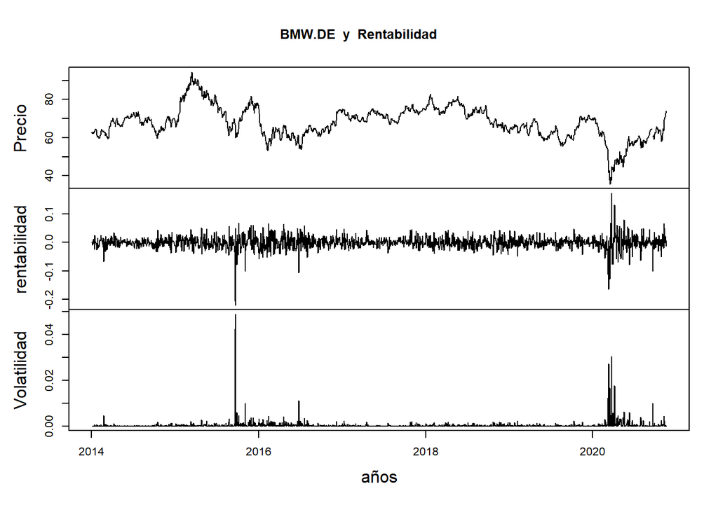

### Testing mean

```
##
##  One Sample t-test
##
## data:  dRentCont
## t = -0.10806, df = 1742, p-value = 0.914
## alternative hypothesis: true mean is not equal to 0
## 95 percent confidence interval:
##  -0.0011050150  0.0009896149
## sample estimates:
##     mean of x
## -5.770006e-05
```

Reprsentacion de la Función de autocorrelación simple y Función de autocorrelación parcial (ACF & PACF):

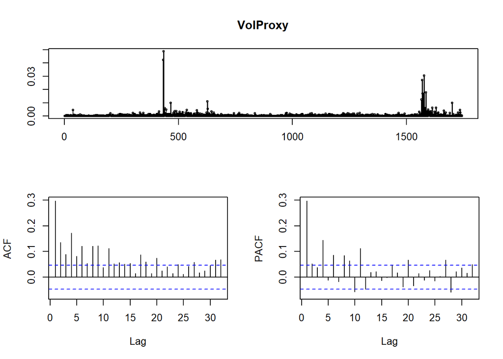

Tras observar los gráficos de ACF Y PACF, se puede concluir que existe autocorrelación y autocorrelación parcial entre los retardos.

### Ljung-Box Test:

La prueba de Box-Ljung es una herramienta de diagnóstico utilizada para probar la falta de ajuste de un modelo de serie temporal.

```
##
##  Box-Ljung test
##
## data:  VolProxy
## X-squared = 349.14, df = 10, p-value < 2.2e-16
```

```
##
##  Box-Ljung test
##
## data:  VolProxy
## X-squared = 421.11, df = 20, p-value < 2.2e-16
```

```
##
##  Box-Ljung test
##
## data:  VolProxy
## X-squared = 466.03, df = 40, p-value < 2.2e-16
```

### LM test

```
##
## Call:
## lm(formula = atsq ~ x)
##
## Residuals:
##       Min        1Q    Median        3Q       Max
## -0.012287 -0.000351 -0.000204  0.000045  0.041687
##
## Coefficients:
##               Estimate Std. Error t value Pr(>|t|)
## (Intercept)  1.936e-04  5.507e-05   3.517 0.000449 ***
## x1           2.927e-01  2.419e-02  12.104  < 2e-16 ***
## x2           7.933e-03  2.517e-02   0.315 0.752642
## x3          -1.449e-02  2.516e-02  -0.576 0.564652
## x4           1.490e-01  2.514e-02   5.928 3.70e-09 ***
## x5          -5.998e-02  2.539e-02  -2.362 0.018274 *
## x6           9.965e-02  2.543e-02   3.918 9.27e-05 ***
## x7          -6.004e-02  2.554e-02  -2.350 0.018865 *
## x8           7.859e-02  2.558e-02   3.072 0.002161 **
## x9           6.042e-02  2.564e-02   2.356 0.018569 *
## x10         -8.145e-02  2.552e-02  -3.192 0.001439 **
## x11          1.210e-01  2.552e-02   4.740 2.31e-06 ***
## x12         -5.832e-02  2.564e-02  -2.274 0.023070 *
## x13          1.470e-02  2.561e-02   0.574 0.566158
## x14          1.378e-02  2.558e-02   0.539 0.590214
## x15         -3.379e-03  2.546e-02  -0.133 0.894439
## x16         -2.655e-02  2.542e-02  -1.044 0.296481
## x17          4.467e-02  2.517e-02   1.774 0.076198 .
## x18          2.779e-02  2.520e-02   1.103 0.270250
## x19         -5.780e-02  2.520e-02  -2.293 0.021960 *
## x20          6.655e-02  2.422e-02   2.747 0.006076 **
## ---
## Signif. codes:  0 '***' 0.001 '**' 0.01 '*' 0.05 '.' 0.1 ' ' 1
##
## Residual standard error: 0.001969 on 1702 degrees of freedom
## Multiple R-squared:  0.1513, Adjusted R-squared:  0.1413
## F-statistic: 15.17 on 20 and 1702 DF,  p-value: < 2.2e-16
```

### ARCH(1,1)

```
##
## Title:
##  GARCH Modelling
##
## Call:
##  garchFit(formula = ~1 + garch(1, 0), data = dRentCont, trace = F)
##
## Mean and Variance Equation:
##  data ~ 1 + garch(1, 0)
## <environment: 0x0000000026ac0180>
##  [data = dRentCont]
##
## Conditional Distribution:
##  norm
##
## Coefficient(s):
##         mu       omega      alpha1
## 0.00045371  0.00037632  0.26342364
##
## Std. Errors:
##  based on Hessian
##
## Error Analysis:
##         Estimate  Std. Error  t value Pr(>|t|)
## mu     4.537e-04   4.990e-04    0.909    0.363
## omega  3.763e-04   1.779e-05   21.159  < 2e-16 ***
## alpha1 2.634e-01   5.118e-02    5.147 2.65e-07 ***
## ---
## Signif. codes:  0 '***' 0.001 '**' 0.01 '*' 0.05 '.' 0.1 ' ' 1
##
## Log Likelihood:
##  4226.949    normalized:  2.4251
##
## Description:
##  Mon Nov 30 15:56:36 2020 by user: 34639
##
##
## Standardised Residuals Tests:
##                                 Statistic p-Value
##  Jarque-Bera Test   R    Chi^2  9188.705  0
##  Shapiro-Wilk Test  R    W      0.9048909 0
##  Ljung-Box Test     R    Q(10)  35.07077  0.00012144
##  Ljung-Box Test     R    Q(15)  40.81441  0.0003413001
##  Ljung-Box Test     R    Q(20)  49.59155  0.0002533255
##  Ljung-Box Test     R^2  Q(10)  463.7931  0
##  Ljung-Box Test     R^2  Q(15)  551.1143  0
##  Ljung-Box Test     R^2  Q(20)  634.095   0
##  LM Arch Test       R    TR^2   288.7281  0
##
## Information Criterion Statistics:
##       AIC       BIC       SIC      HQIC
## -4.846757 -4.837354 -4.846763 -4.843280
```

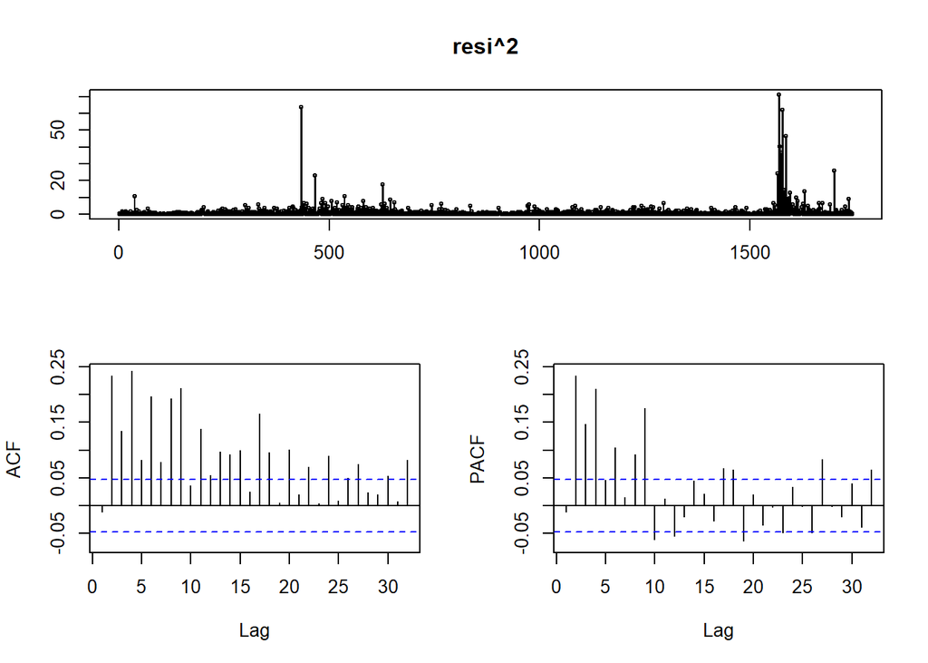

### GARCH(1,1)

```
##
## Title:
##  GARCH Modelling
##
## Call:
##  garchFit(formula = ~1 + garch(1, 1), data = dRentCont, trace = F)
##
## Mean and Variance Equation:
##  data ~ 1 + garch(1, 1)
## <environment: 0x000000002459c870>
##  [data = dRentCont]
##
## Conditional Distribution:
##  norm
##
## Coefficient(s):
##         mu       omega      alpha1       beta1
## 3.6746e-04  3.5182e-06  6.9032e-02  9.2833e-01
##
## Std. Errors:
##  based on Hessian
##
## Error Analysis:
##         Estimate  Std. Error  t value Pr(>|t|)
## mu     3.675e-04   4.048e-04    0.908   0.3640
## omega  3.518e-06   1.380e-06    2.550   0.0108 *
## alpha1 6.903e-02   9.466e-03    7.292 3.05e-13 ***
## beta1  9.283e-01   9.286e-03   99.972  < 2e-16 ***
## ---
## Signif. codes:  0 '***' 0.001 '**' 0.01 '*' 0.05 '.' 0.1 ' ' 1
##
## Log Likelihood:
##  4430.883    normalized:  2.542101
##
## Description:
##  Mon Nov 30 15:56:37 2020 by user: 34639
##
##
## Standardised Residuals Tests:
##                                 Statistic p-Value
##  Jarque-Bera Test   R    Chi^2  4192.867  0
##  Shapiro-Wilk Test  R    W      0.9540295 0
##  Ljung-Box Test     R    Q(10)  32.98751  0.0002737054
##  Ljung-Box Test     R    Q(15)  34.18205  0.003210479
##  Ljung-Box Test     R    Q(20)  35.75645  0.0164263
##  Ljung-Box Test     R^2  Q(10)  15.50828  0.1146003
##  Ljung-Box Test     R^2  Q(15)  16.17153  0.3707444
##  Ljung-Box Test     R^2  Q(20)  19.35141  0.4991007
##  LM Arch Test       R    TR^2   16.04931  0.1889878
##
## Information Criterion Statistics:
##       AIC       BIC       SIC      HQIC
## -5.079613 -5.067075 -5.079623 -5.074977
```

Tanto para el ARCH(1,1) como para el GARCH(1,1) obtenemos el AIC y el BIC. Si comparamos el AIC, se prefiere el GRANCH(1,1).

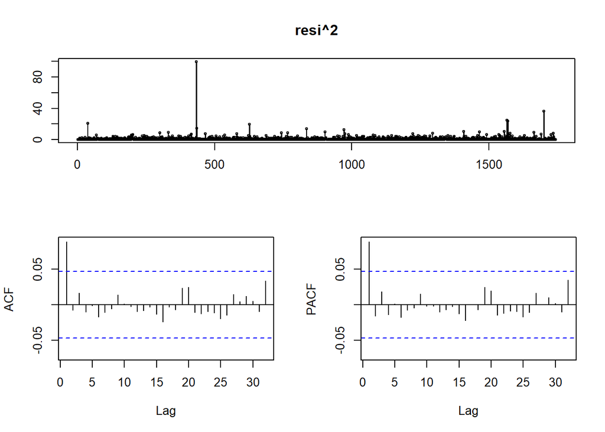

### t-student

```
##
## Title:
##  GARCH Modelling
##
## Call:
##  garchFit(formula = ~1 + garch(1, 1), data = dRentCont, cond.dist = "std",
##     trace = F)
##
## Mean and Variance Equation:
##  data ~ 1 + garch(1, 1)
## <environment: 0x0000000021ad6968>
##  [data = dRentCont]
##
## Conditional Distribution:
##  std
##
## Coefficient(s):
##         mu       omega      alpha1       beta1       shape
## 6.8286e-05  4.7613e-06  5.8159e-02  9.3170e-01  5.4579e+00
##
## Std. Errors:
##  based on Hessian
##
## Error Analysis:
##         Estimate  Std. Error  t value Pr(>|t|)
## mu     6.829e-05   3.739e-04    0.183  0.85509
## omega  4.761e-06   1.777e-06    2.680  0.00737 **
## alpha1 5.816e-02   1.246e-02    4.667 3.06e-06 ***
## beta1  9.317e-01   1.292e-02   72.098  < 2e-16 ***
## shape  5.458e+00   7.002e-01    7.794 6.44e-15 ***
## ---
## Signif. codes:  0 '***' 0.001 '**' 0.01 '*' 0.05 '.' 0.1 ' ' 1
##
## Log Likelihood:
##  4520.338    normalized:  2.593424
##
## Description:
##  Mon Nov 30 15:56:38 2020 by user: 34639
##
##
## Standardised Residuals Tests:
##                                 Statistic p-Value
##  Jarque-Bera Test   R    Chi^2  4664.045  0
##  Shapiro-Wilk Test  R    W      0.9518086 0
##  Ljung-Box Test     R    Q(10)  33.03012  0.0002692288
##  Ljung-Box Test     R    Q(15)  34.3241   0.003065873
##  Ljung-Box Test     R    Q(20)  35.83185  0.01609595
##  Ljung-Box Test     R^2  Q(10)  19.68552  0.03237149
##  Ljung-Box Test     R^2  Q(15)  20.11465  0.1675786
##  Ljung-Box Test     R^2  Q(20)  23.65921  0.2575956
##  LM Arch Test       R    TR^2   20.22594  0.06293087
##
## Information Criterion Statistics:
##       AIC       BIC       SIC      HQIC
## -5.181111 -5.165439 -5.181127 -5.175316
```

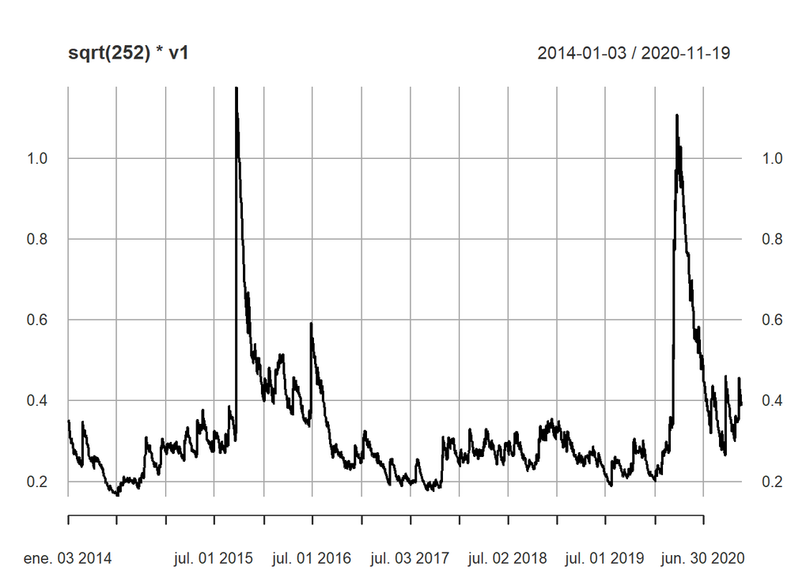

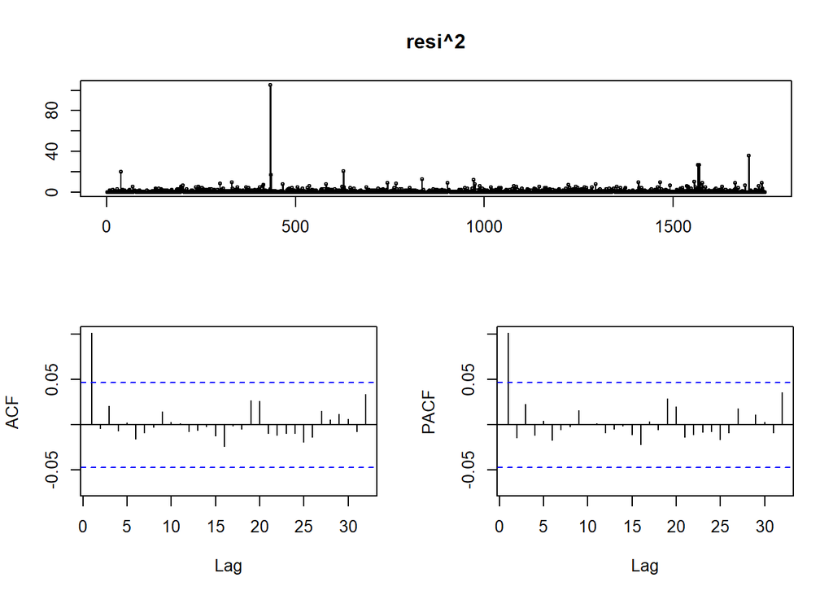

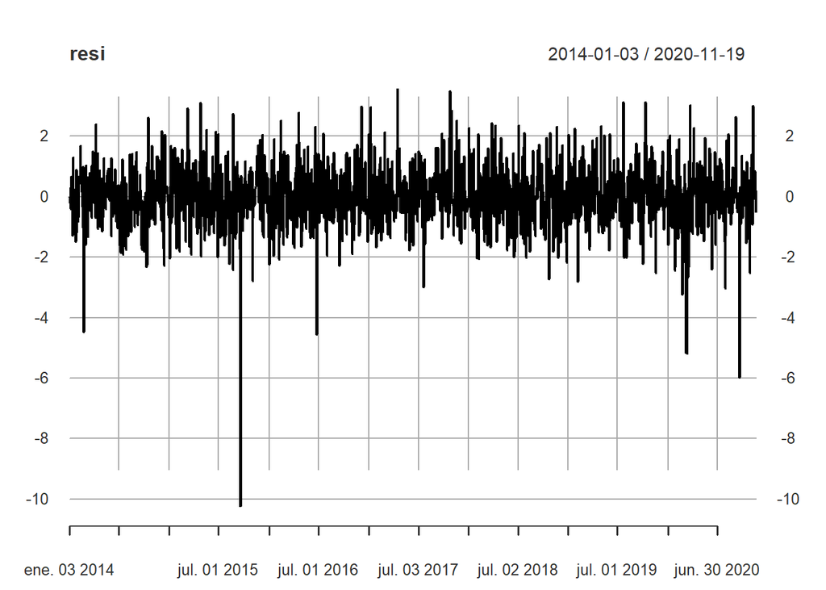

| meanForecast | meanError | standardDeviation |
| --- | --- | --- |
| 6.828553e-05 | 0.02383014 | 0.02383014 |
| 6.828553e-05 | 0.02380918 | 0.02380918 |
| 6.828553e-05 | 0.02378842 | 0.02378842 |
| 6.828553e-05 | 0.02376785 | 0.02376785 |
| 6.828553e-05 | 0.02374747 | 0.02374747 |
| 6.828553e-05 | 0.02372729 | 0.02372729 |
| 6.828553e-05 | 0.02370728 | 0.02370728 |
| 6.828553e-05 | 0.02368747 | 0.02368747 |
| 6.828553e-05 | 0.02366784 | 0.02366784 |
| 6.828553e-05 | 0.02364839 | 0.02364839 |

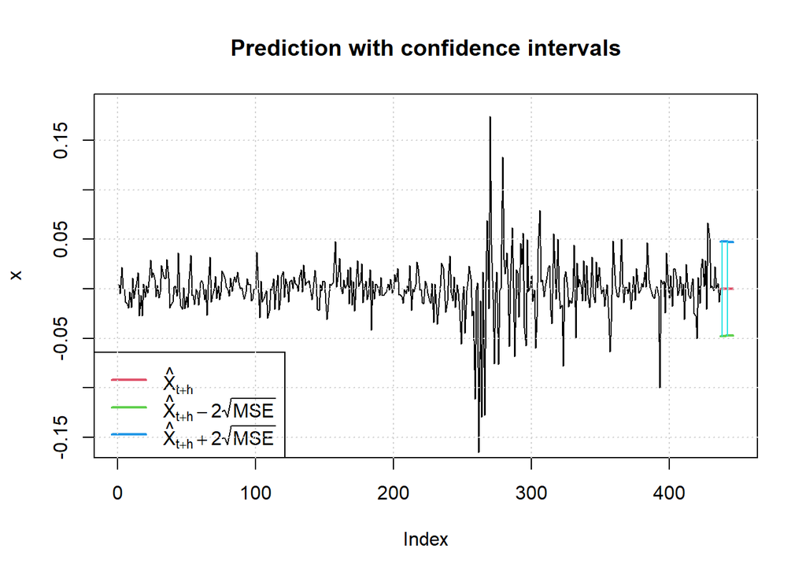

| meanForecast | meanError | standardDeviation | lowerInterval | upperInterval |
| --- | --- | --- | --- | --- |
| 6.828553e-05 | 0.02383014 | 0.02383014 | -0.04759199 | 0.04772856 |
| 6.828553e-05 | 0.02380918 | 0.02380918 | -0.04755008 | 0.04768665 |
| 6.828553e-05 | 0.02378842 | 0.02378842 | -0.04750856 | 0.04764513 |
| 6.828553e-05 | 0.02376785 | 0.02376785 | -0.04746742 | 0.04760399 |
| 6.828553e-05 | 0.02374747 | 0.02374747 | -0.04742666 | 0.04756323 |
| 6.828553e-05 | 0.02372729 | 0.02372729 | -0.04738629 | 0.04752286 |
| 6.828553e-05 | 0.02370728 | 0.02370728 | -0.04734628 | 0.04748285 |
| 6.828553e-05 | 0.02368747 | 0.02368747 | -0.04730665 | 0.04744323 |
| 6.828553e-05 | 0.02366784 | 0.02366784 | -0.04726739 | 0.04740397 |
| 6.828553e-05 | 0.02364839 | 0.02364839 | -0.04722850 | 0.04736507 |

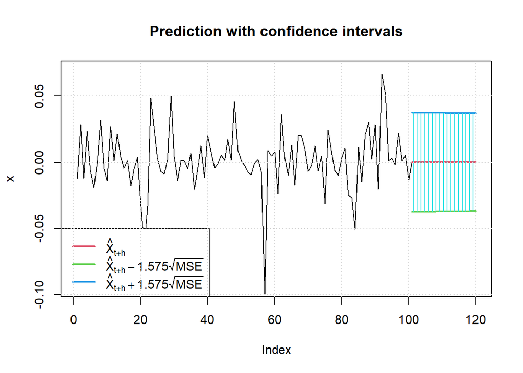

| meanForecast | meanError | standardDeviation | lowerInterval | upperInterval |
| --- | --- | --- | --- | --- |
| 6.828553e-05 | 0.02383014 | 0.02383014 | -0.03745592 | 0.03759249 |
| 6.828553e-05 | 0.02380918 | 0.02380918 | -0.03742292 | 0.03755949 |
| 6.828553e-05 | 0.02378842 | 0.02378842 | -0.03739023 | 0.03752680 |
| 6.828553e-05 | 0.02376785 | 0.02376785 | -0.03735784 | 0.03749441 |
| 6.828553e-05 | 0.02374747 | 0.02374747 | -0.03732575 | 0.03746232 |
| 6.828553e-05 | 0.02372729 | 0.02372729 | -0.03729396 | 0.03743053 |
| 6.828553e-05 | 0.02370728 | 0.02370728 | -0.03726247 | 0.03739904 |
| 6.828553e-05 | 0.02368747 | 0.02368747 | -0.03723127 | 0.03736784 |
| 6.828553e-05 | 0.02366784 | 0.02366784 | -0.03720036 | 0.03733693 |
| 6.828553e-05 | 0.02364839 | 0.02364839 | -0.03716973 | 0.03730631 |

[output cut: 10 more lines]

## 4. Modelos VAR

Las relaciones de retroalimentación (bidirecionalidad) se modelizancon los vectores autorregresivos (VAR).

En un VAR, todas las variables son tratadas simétricamente.

### Seleccionar modelo.

Para una selección de modelo más establecida, puede considerar el uso de VARselect(), que proporciona múltiples criterios de información.

```
## $selection
## AIC(n)  HQ(n)  SC(n) FPE(n)
##      1      1      1      1
##
## $criteria
##                    1             2             3             4             5
## AIC(n) -1.027091e+01 -1.026427e+01 -1.018196e+01 -1.009523e+01 -1.001417e+01
## HQ(n)  -1.019589e+01 -1.013923e+01 -1.000691e+01 -9.870156e+00 -9.739087e+00
## SC(n)  -1.008266e+01 -9.950510e+00 -9.742697e+00 -9.530456e+00 -9.323898e+00
## FPE(n)  3.462891e-05  3.487145e-05  3.789160e-05  4.138032e-05  4.496849e-05
##                    6             7             8             9            10
## AIC(n) -1.004351e+01 -1.002932e+01 -9.981617e+00 -9.910458e+00 -9.946144e+00
## HQ(n)  -9.718409e+00 -9.654200e+00 -9.556483e+00 -9.435308e+00 -9.420978e+00
## SC(n)  -9.227731e+00 -9.088034e+00 -8.914828e+00 -8.718164e+00 -8.628345e+00
## FPE(n)  4.380184e-05  4.461463e-05  4.705431e-05  5.088488e-05  4.954017e-05
```

### Estimación

Los parámetros estimados y otros múltiples resultados estadísticos pueden obtenerse mediante el método summary():

```r
model.var=VAR(vY)
summary(model.var)
```

```
##
## VAR Estimation Results:
## =========================
## Endogenous variables: BMW, VOLW
## Deterministic variables: const
## Sample size: 82
## Log Likelihood: 200.966
## Roots of the characteristic polynomial:
## 0.2883 0.2883
## Call:
## VAR(y = vY)
##
##
## Estimation results for equation BMW:
## ====================================
## BMW = BMW.l1 + VOLW.l1 + const
##
##          Estimate Std. Error t value Pr(>|t|)
## BMW.l1   0.280649   0.164325   1.708  0.09158 .
## VOLW.l1 -0.354018   0.124637  -2.840  0.00573 **
## const    0.005696   0.008559   0.666  0.50765
## ---
## Signif. codes:  0 '***' 0.001 '**' 0.01 '*' 0.05 '.' 0.1 ' ' 1
##
##
## Residual standard error: 0.07748 on 79 degrees of freedom
## Multiple R-Squared: 0.09503, Adjusted R-squared: 0.07212
## F-statistic: 4.148 on 2 and 79 DF,  p-value: 0.01937
##
##
## Estimation results for equation VOLW:
## =====================================
## VOLW = BMW.l1 + VOLW.l1 + const
##
##          Estimate Std. Error t value Pr(>|t|)
## BMW.l1   0.518407   0.210225   2.466   0.0158 *
## VOLW.l1 -0.357848   0.159451  -2.244   0.0276 *
## const    0.004729   0.010950   0.432   0.6670
## ---
## Signif. codes:  0 '***' 0.001 '**' 0.01 '*' 0.05 '.' 0.1 ' ' 1
##
##
## Residual standard error: 0.09912 on 79 degrees of freedom
## Multiple R-Squared: 0.07649, Adjusted R-squared: 0.05311
## F-statistic: 3.272 on 2 and 79 DF,  p-value: 0.04314
##
##
##
## Covariance matrix of residuals:
##           BMW     VOLW
## BMW  0.006002 0.005613
## VOLW 0.005613 0.009824
##
## Correlation matrix of residuals:
##        BMW  VOLW
## BMW  1.000 0.731
## VOLW 0.731 1.000
```

```
##
## VAR Estimation Results:
## =========================
## Endogenous variables: BMW, VOLW
## Deterministic variables: none
## Sample size: 82
## Log Likelihood: 200.733
## Roots of the characteristic polynomial:
## 0.2881 0.2881
## Call:
## VAR(y = vY, type = "none")
##
##
## Estimation results for equation BMW:
## ====================================
## BMW = BMW.l1 + VOLW.l1
##
##         Estimate Std. Error t value Pr(>|t|)
## BMW.l1    0.2830     0.1637   1.729  0.08772 .
## VOLW.l1  -0.3543     0.1242  -2.852  0.00552 **
## ---
## Signif. codes:  0 '***' 0.001 '**' 0.01 '*' 0.05 '.' 0.1 ' ' 1
##
##
## Residual standard error: 0.07721 on 80 degrees of freedom
## Multiple R-Squared: 0.0945,  Adjusted R-squared: 0.07186
## F-statistic: 4.174 on 2 and 80 DF,  p-value: 0.01886
##
##
## Estimation results for equation VOLW:
## =====================================
## VOLW = BMW.l1 + VOLW.l1
##
##         Estimate Std. Error t value Pr(>|t|)
## BMW.l1    0.5204     0.2091   2.489   0.0149 *
## VOLW.l1  -0.3581     0.1586  -2.257   0.0267 *
## ---
## Signif. codes:  0 '***' 0.001 '**' 0.01 '*' 0.05 '.' 0.1 ' ' 1
##
##
## Residual standard error: 0.09861 on 80 degrees of freedom
## Multiple R-Squared: 0.07673, Adjusted R-squared: 0.05365
## F-statistic: 3.324 on 2 and 80 DF,  p-value: 0.04104
##
##
##
## Covariance matrix of residuals:
##           BMW     VOLW
## BMW  0.005927 0.005543
## VOLW 0.005543 0.009701
##
## Correlation matrix of residuals:
##        BMW  VOLW
## BMW  1.000 0.731
## VOLW 0.731 1.000
```

```
## $Granger
##
##  Granger causality H0: BMW do not Granger-cause VOLW
##
## data:  VAR object model.var1
## F-Test = 6.193, df1 = 1, df2 = 160, p-value = 0.01385
##
##
## $Instant
##
##  H0: No instantaneous causality between: BMW and VOLW
##
## data:  VAR object model.var1
## Chi-squared = 28.594, df = 1, p-value = 8.927e-08
```

Las respuestas de impulso son generadas numéricamente por irf()

```
##
## Impulse response coefficients
## $BMW
##                 BMW          VOLW
##  [1,]  7.720553e-02  7.215505e-02
##  [2,] -3.713073e-03  1.433906e-02
##  [3,] -6.130922e-03 -7.066521e-03
##  [4,]  7.684115e-04 -6.600561e-04
##  [5,]  4.513166e-04  6.362027e-04
##  [6,] -9.766679e-05  7.048114e-06
##  [7,] -3.013800e-05 -5.334655e-05
##  [8,]  1.037028e-05  3.418754e-06
##  [9,]  1.723723e-06  4.172239e-06
## [10,] -9.903139e-07 -5.969695e-07
## [11,] -6.877614e-08 -3.015742e-07
```

[output cut: 74 more lines]

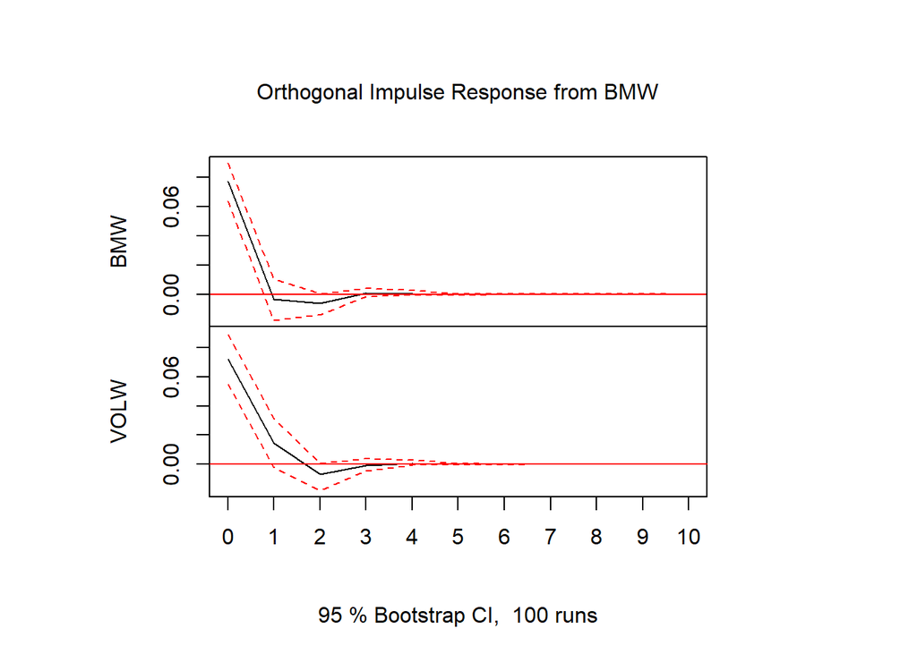

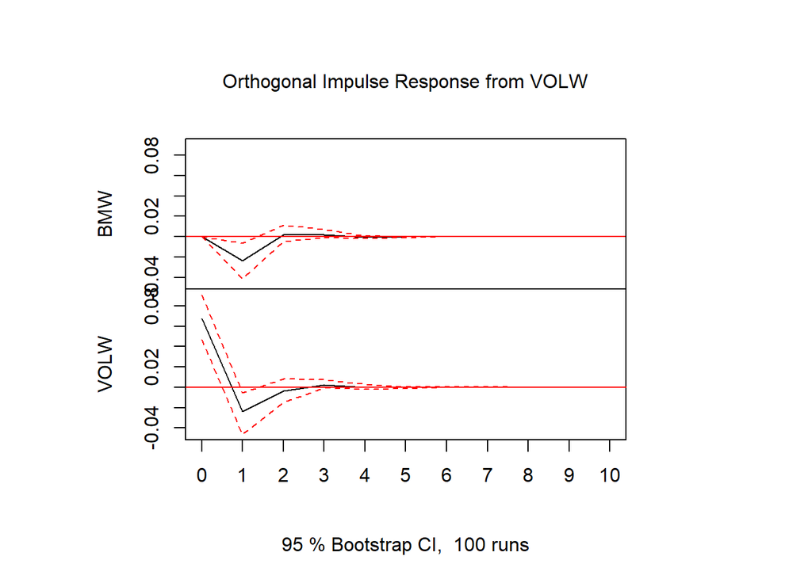

### Prediccion

```
## $BMW
##               fcst      lower     upper        CI
## [1,] -3.765025e-03 -0.1550851 0.1475550 0.1513201
## [2,] -2.139204e-02 -0.1799135 0.1371294 0.1585214
## [3,]  1.918137e-03 -0.1570967 0.1609330 0.1590148
## [4,]  1.632003e-03 -0.1574310 0.1606950 0.1590630
## [5,] -2.817326e-04 -0.1593481 0.1587847 0.1590664
## [6,] -1.143436e-04 -0.1591811 0.1589524 0.1590667
## [7,]  3.197142e-05 -0.1590348 0.1590987 0.1590668
## [8,]  7.093218e-06 -0.1590597 0.1590739 0.1590668
##
## $VOLW
##               fcst      lower     upper        CI
## [1,]  5.737372e-02 -0.1359006 0.2506480 0.1932743
## [2,] -2.250286e-02 -0.2234255 0.1784198 0.2009227
## [3,] -3.074230e-03 -0.2046095 0.1984610 0.2015353
## [4,]  2.098922e-03 -0.1994901 0.2036879 0.2015890
## [5,]  9.768947e-05 -0.2014954 0.2016907 0.2015930
## [6,] -1.815845e-04 -0.2017750 0.2014118 0.2015934
## [7,]  5.518521e-06 -0.2015879 0.2015990 0.2015935
## [8,]  1.466096e-05 -0.2015788 0.2016081 0.2015935
```